# Propensity Score e Matching

## Introdução

Quando não dispomos de um experimento aleatorizado, como podemos estimar efeitos causais? A estratégia de **seleção em observáveis** parte da seguinte ideia: se observamos todas as variáveis que afetam simultaneamente o tratamento e o resultado, podemos comparar unidades tratadas e não-tratadas que sejam “semelhantes” nessas variáveis. Neste capítulo, apresentamos três ferramentas para implementar essa ideia: o propensity score, o matching e a ponderação por probabilidade inversa (IPW).

## Suposições de identificação

Antes de apresentar os métodos, é fundamental explicitar as suposições que garantem a identificação causal nesse contexto. Supondo um tratamento binário $D$ e um vetor de covariáveis $X$, precisamos de duas condições:

1. $(Y_i(1), Y_i(0)) \perp D_i|X_i$ (Independência Condicional, ou CIA)
2. $0 < P(D_i=1|X_i) < 1$ (Suporte comum)

A primeira condição diz que, condicional às covariáveis, o tratamento é como se fosse aleatório — não há confundidores não-observados. A segunda garante que, para cada perfil de covariáveis, existe chance positiva de observar tanto tratados quanto controles.

Sob essas condições, podemos derivar a identificação do efeito causal. Usando independência condicional e a *switching equation*:

$$\begin{align}
\mathbb{E}[Y_i(1)-Y_i(0)|X] & = \mathbb{E}[Y_i(1) - Y_i(0) | X,
D=1] \\
& = \mathbb{E}[Y_i(1)| X, D=1] - \mathbb{E}[Y_i(0)|
X,D=0] \\
& = \mathbb{E}[Y| X, D=1] - \mathbb{E}[Y| X, D=0]
\end{align}$$

E o estimador do ATE pode ser representado (supondo suporte comum) como:

$$\widehat{\delta}_{ATE} = \sum_{x\in
X}{(\mathbb{E}[Y| X=x, D=1] - \mathbb{E}[Y| X=x,
D=0])P(X=x)}$$

Ou seja, computamos a média do efeito do tratamento condicional ponderado pela distribuição de $X$.

Para identificar o ATE, precisamos supor independência condicional para ambos os resultados potenciais. Se porém isso for crível apenas para $Y_i(0)$, podemos estimar o ATT. Basta lembrar que $\mathbb{E}[Y_i|D_i=1] - \mathbb{E}[Y_i|D_i=0] = \mathbb{E}[Y_i(1) - Y_i(0)|D_i=1] + \mathbb{E}[Y_i(0)|D_i=1] - \mathbb{E}[Y_i(0)|D_i=0]$

## Propensity Score

O propensity score nada mais é que a probabilidade de uma unidade ser tratada, dadas as covariáveis, ou seja, $Pr(D_i = 1| X_i)$.

A ideia chave para propensity score vem de um paper de @rosenbaumrubin1983 em que eles mostram (Teorema 3 do artigo) que, se a condição de ignorabilidade forte for satisfeita (isto é, $Y_i(1), Y_i(0) \perp D_i|X_i$), então também é verdade que $Y_i(1), Y_i(0) \perp D_i|\pi(X_i)$, em que $\pi(X_i) = P(D_i = 1|X_i)$ é o propensity score verdadeiro. Isso é um resultado de **redução de dimensionalidade**: em vez de condicionar em todo o vetor $X_i$ — que pode ter dezenas de variáveis — podemos condicionar em um único escalar $\pi(X_i)$.

Por que a redução dimensional importa? Condicionar diretamente em $X$ equivale a comparar tratados e controles dentro de cada combinação de covariáveis. Se temos 10 variáveis binárias, são $2^{10} = 1024$ células; com variáveis contínuas, o número de combinações é efetivamente infinito. À medida que a dimensão de $X$ cresce, muitas células ficam vazias ou com poucas observações — é a chamada **maldição da dimensionalidade**. O propensity score contorna esse problema ao colapsar toda a informação relevante sobre a seleção ao tratamento em um número entre 0 e 1.

Em princípio, poderíamos estimar o propensity score de forma **não-paramétrica**, calculando diretamente a fração de tratados em cada combinação de $X$ (o Teorema 5 de @rosenbaumrubin1983 mostra que esse estimador produz balanceamento amostral). Porém, isso sofre da mesma maldição da dimensionalidade: só funciona quando $X$ é discreto e a amostra é grande o suficiente para que cada combinação tenha observações nos dois grupos. Na prática, precisamos impor um modelo paramétrico — tipicamente logit ou probit — para estimar $\hat{\pi}(X)$, e esse modelo pode estar mal especificado.

É importante perceber que o propensity score **não elimina** o problema de especificação de modelo — ele o **transfere** do modelo de outcome ($E[Y|X,D]$) para o modelo de tratamento ($P(D=1|X)$). Especificar corretamente $P(D=1|X)$ é, em princípio, tão difícil quanto especificar $E[Y|X,D]$. A vantagem do propensity score está em outro lugar: o modelo de tratamento é **diagnosticável**. Se $\hat{\pi}(X)$ está errado, o desbalanceamento residual nas covariáveis aparece nos diagnósticos de balanceamento — podemos verificar diretamente se $X \perp D | \hat{\pi}(X)$. Já o modelo de outcome não pode ser testado dessa forma, pois nunca observamos ambos os resultados potenciais para a mesma unidade. Além disso, o propensity score separa o “desenho” do estudo (construir grupos comparáveis) da “análise” (estimar o efeito), o que reduz os graus de liberdade do pesquisador — de modo análogo a um experimentalista que desenha o experimento antes de olhar os resultados.

Para ilustrar a importância da redução dimensional e da diagnosticabilidade, vamos considerar um exemplo simulado em que ignorabilidade forte é satisfeita, mas um modelo mal-especificado do outcome gera estimativas viesadas — enquanto o propensity score consegue recuperar o efeito causal.

```r
library(knitr)
library(tidyverse)
library(broom)
library(kableExtra)
library(ggdag)
library(MatchIt)
library(data.table)
library(here, quietly=TRUE)
library(marginaleffects)
```

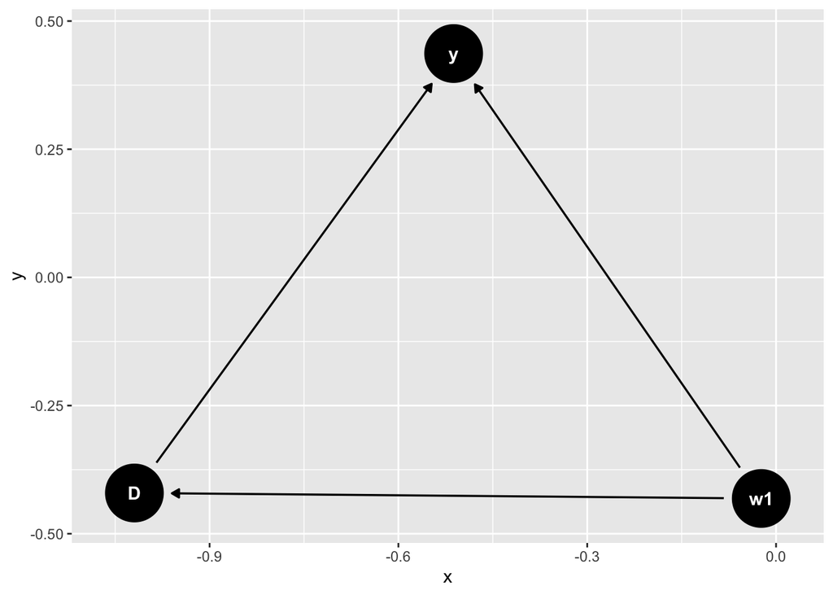

```r
# true DGP
dag <- dagify(
  y ~ D + w1,
  D ~ w1
)

ggdag(dag)
```

O DAG acima ilustra bem qual a relação causal entre variáveis. Para estimar o ATE de $D$ sobre $Y$, precisamos fechar o backdoor de $w_1$. A forma usual como fazemos isso é com regressão. O problema que estamos abordando aqui é quando a amostra é não-balanceada entre tratados e não-tratados. Vamos visualizar dois tipos de relações (uma linear e outra não-linear) entre a variável de controle $w_1$ e a resposta $Y$ para ilustrar o problema do desbalanceamento:

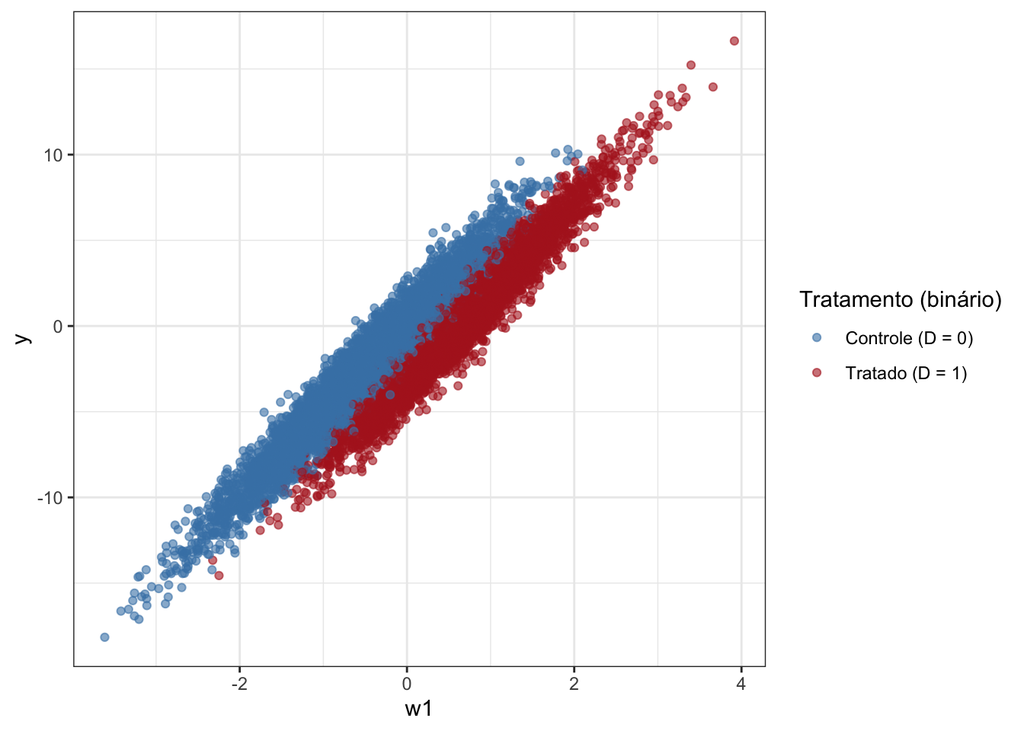

```r
set.seed(202)
n  <- 1e4
w1 <- rnorm(n)                       # único confundidor
tau <- 3                             # efeito causal verdadeiro

# GERAMOS UM PROPENSITY SCORE NÃO‐LINEAR
p  <- plogis(-0.5 + 2 * w1)
D  <- rbinom(n, 1, p)

# GERAÇÃO DOS RESULTADOS POTENCIAIS linear (apenas função de w1, forte ignorabilidade):
y0 <-  5 * w1 + rnorm(n)
y1 <- y0 - tau                       # efeito constante

y  <- ifelse(D == 1, y1, y0)



df <- data.frame(y=y, D=D, w1=w1)

df %>%
  mutate(
    D = factor(D, levels = c(0,1),
               labels = c("Controle (D = 0)", "Tratado (D = 1)"))
  ) %>%
  ggplot(aes(x = w1, y = y, colour = D)) +
  geom_point(alpha = 0.6) +
  scale_colour_manual(
    name   = "Tratamento (binário)",
    values = c("Controle (D = 0)" = "steelblue",
               "Tratado (D = 1)"  = "firebrick")
  ) + theme_bw()
```

No primeiro gráfico, o efeito causal (ATE) do tratamento é $-3$ e podemos ver nos dados que de fato em média a resposta é menor entre tratados que no controle. Além disso, vemos também que o efeito é basicamente linear.

Mas o ponto importante aqui é que existem duas regiões dos dados em que praticamente só temos unidades no controle ($w_1 < -2$) ou no tratamento ($w_1 > 2$). Isso significa que a regressão precisa extrapolar a estimativa da região em que ambos tratamento e controle estão presentes para uma região em que não estão. Como o efeito é constante para todas as regiões de $w_1$, isso não causa problema e a regressão consegue recuperar o ATE sem viés. O gráfico abaixo ilustra o que a regressão está fazendo:

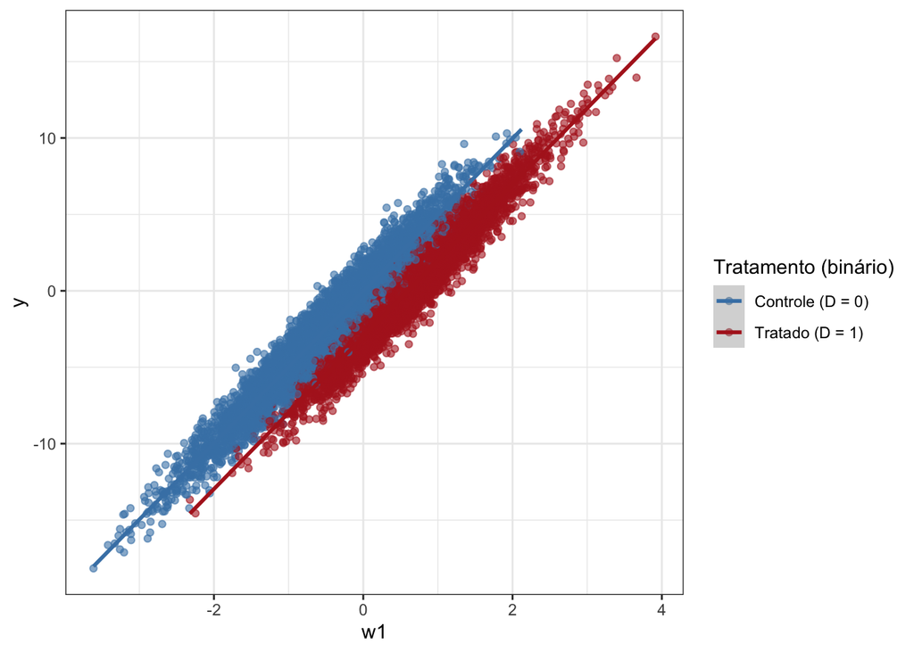

```r
df %>%
  mutate(
    D = factor(D, levels = c(0,1),
               labels = c("Controle (D = 0)", "Tratado (D = 1)"))
  ) %>%
  ggplot(aes(x = w1, y = y, colour = D)) +
  geom_point(alpha = 0.6) +
  geom_smooth(method = "lm") +
  scale_colour_manual(
    name   = "Tratamento (binário)",
    values = c("Controle (D = 0)" = "steelblue",
               "Tratado (D = 1)"  = "firebrick")
  ) + theme_bw()
```

O gráfico mostra duas retas de regressão ajustadas, uma para o controle (em azul) e outra para o tratamento (em vermelho). Efetivamente, temos de estender as duas retas para as regiões em que não há dados, por meio de extrapolação, que no caso significa continuar a linha reta. Assim, temos uma estimativa dos resultados potenciais nessas regiões e podemos computar o efeito causal médio. Como a extrapolação é razoável, não há problema.

Vejamos agora uma situação em que o efeito de $w_1$ é não linear sobre $Y$.

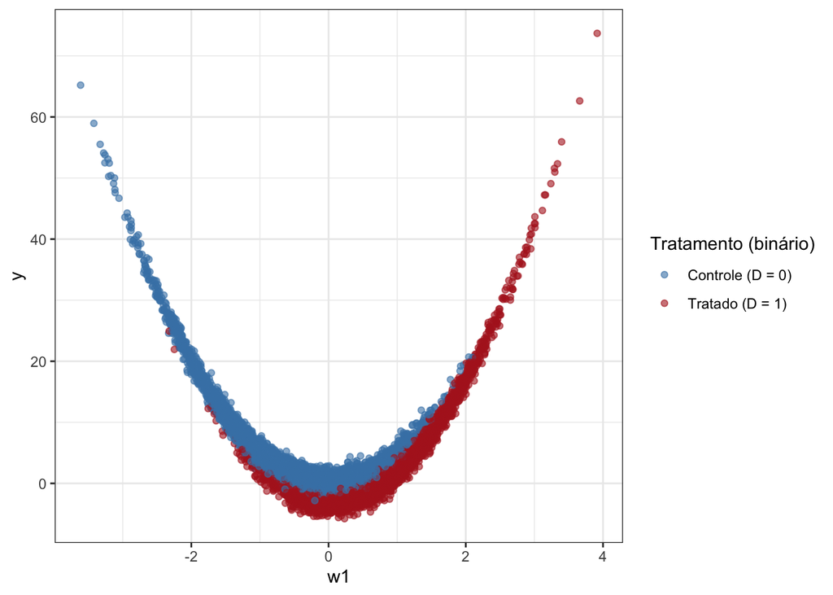

```r
set.seed(202)
n  <- 1e4
w1 <- rnorm(n)                       # único confundidor
tau <- 3                             # efeito causal verdadeiro

# GERAMOS UM PROPENSITY SCORE NÃO‐LINEAR
p  <- plogis(-0.5 + 2 * w1)
D  <- rbinom(n, 1, p)

# GERAÇÃO DOS RESULTADOS POTENCIAIS não-linear (apenas função de w1, forte ignorabilidade):
y0 <-  5 * w1^2 + rnorm(n)
y1 <- y0 - tau                       # efeito constante

y  <- ifelse(D == 1, y1, y0)



df <- data.frame(y=y, D=D, w1=w1)

df %>%
  mutate(
    D = factor(D, levels = c(0,1),
               labels = c("Controle (D = 0)", "Tratado (D = 1)"))
  ) %>%
  ggplot(aes(x = w1, y = y, colour = D)) +
  geom_point(alpha = 0.6) +
  scale_colour_manual(
    name   = "Tratamento (binário)",
    values = c("Controle (D = 0)" = "steelblue",
               "Tratado (D = 1)"  = "firebrick")
  ) + theme_bw()
```

Aqui, vemos que o efeito é não-linear de $w_1$ sobre $Y$ e também o desbalanceamento na amostra. Vamos ver o mesmo gráfico com as duas retas ajustadas para entender como a extrapolação pode produzir estimativas distorcidas nesse caso.

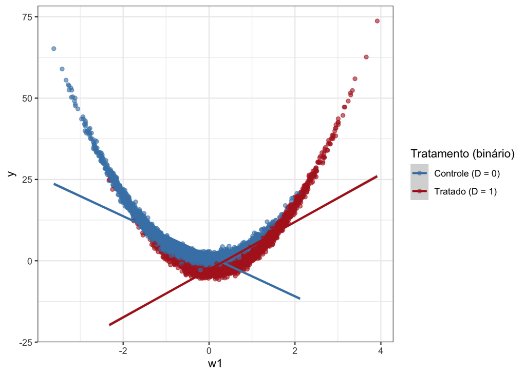

```r
df %>%
  mutate(
    D = factor(D, levels = c(0,1),
               labels = c("Controle (D = 0)", "Tratado (D = 1)"))
  ) %>%
  ggplot(aes(x = w1, y = y, colour = D)) +
  geom_point(alpha = 0.6) +
  geom_smooth(method = "lm") +
  scale_colour_manual(
    name   = "Tratamento (binário)",
    values = c("Controle (D = 0)" = "steelblue",
               "Tratado (D = 1)"  = "firebrick")
  ) + theme_bw()
```

Um problema óbvio do modelo é que o efeito de w1 é quadrático, então podemos tentar corrigir isso incluindo um termo quadrático.

```r
reg_sq <- lm(y ~ D + w1 + I(w1^2), data = df)
summary(reg_sq)
```

```
##
## Call:
## lm(formula = y ~ D + w1 + I(w1^2), data = df)
##
## Residuals:
##     Min      1Q  Median      3Q     Max
## -3.5311 -0.6586 -0.0043  0.6679  3.8928
##
## Coefficients:
##              Estimate Std. Error  t value Pr(>|t|)
## (Intercept) -0.012244   0.015950   -0.768    0.443
## D           -2.996063   0.025632 -116.890   <2e-16 ***
## w1          -0.013777   0.012639   -1.090    0.276
## I(w1^2)      5.005598   0.007154  699.737   <2e-16 ***
## ---
## Signif. codes:  0 '***' 0.001 '**' 0.01 '*' 0.05 '.' 0.1 ' ' 1
##
## Residual standard error: 0.9976 on 9996 degrees of freedom
## Multiple R-squared:  0.9806, Adjusted R-squared:  0.9806
## F-statistic: 1.688e+05 on 3 and 9996 DF,  p-value: < 2.2e-16
```

Em resumo, quando há desbalanceamento, a estimativa passa a depender fortemente da especificação do modelo, o que é problemático.

Será que existe uma abordagem que nos permita recuperar o efeito causal sem precisar acertar a forma funcional do modelo de outcome? Vamos testar com o propensity score:

```r
reg_aux<- glm(D  ~ w1, family = binomial, data=df)
p_score <- reg_aux$fitted.values
reg1 <- lm(y ~ D + p_score)
summary(reg1)
```

```
##
## Call:
## lm(formula = y ~ D + p_score)
##
## Residuals:
##    Min     1Q Median     3Q    Max
## -7.921 -4.258 -2.462  1.647 70.708
##
## Coefficients:
##             Estimate Std. Error t value Pr(>|t|)
## (Intercept)   4.2799     0.1179  36.307  < 2e-16 ***
## D            -2.9562     0.1858 -15.910  < 2e-16 ***
## p_score       1.6681     0.2917   5.718 1.11e-08 ***
## ---
## Signif. codes:  0 '***' 0.001 '**' 0.01 '*' 0.05 '.' 0.1 ' ' 1
##
## Residual standard error: 7.069 on 9997 degrees of freedom
## Multiple R-squared:  0.02781,    Adjusted R-squared:  0.02761
## F-statistic:   143 on 2 and 9997 DF,  p-value: < 2.2e-16
```

```r
w <- ifelse(D == 1, 1/p_score, 1/(1-p_score))   # pesos IPTW

reg2 <- lm(y ~ D , weights = w)
summary(reg2)
```

```
##
## Call:
## lm(formula = y ~ D, weights = w)
##
## Weighted Residuals:
##    Min     1Q Median     3Q    Max
## -15.95  -5.52  -2.87   2.04 324.89
##
## Coefficients:
##             Estimate Std. Error t value Pr(>|t|)
## (Intercept)  4.67183    0.09553   48.90   <2e-16 ***
## D           -2.57016    0.13452  -19.11   <2e-16 ***
## ---
## Signif. codes:  0 '***' 0.001 '**' 0.01 '*' 0.05 '.' 0.1 ' ' 1
##
## Residual standard error: 9.499 on 9998 degrees of freedom
## Multiple R-squared:  0.03523,    Adjusted R-squared:  0.03513
## F-statistic: 365.1 on 1 and 9998 DF,  p-value: < 2.2e-16
```

## Ponderação por Probabilidade Inversa (IPW)

O código acima já usa uma das aplicações mais importantes do propensity score: a **ponderação por probabilidade inversa** (IPW, ou IPTW — *Inverse Probability of Treatment Weighting*). A ideia é reponderar as observações de modo que, na amostra repesada, o tratamento seja independente das covariáveis — simulando o que um experimento aleatorizado produziria.

O estimador IPW do ATE é:

$$\hat{\tau}_{IPW} =
\frac{1}{N}\sum_{i=1}^{N} \left[\frac{D_i Y_i}{\hat{\pi}(X_i)} -
\frac{(1-D_i) Y_i}{1-\hat{\pi}(X_i)}\right]$$

A intuição é simples: unidades tratadas com baixa probabilidade de tratamento (baixo $\hat{\pi}$) são “surpreendentes” — representam tipos que normalmente não seriam tratados — e por isso recebem peso maior ($1/\hat{\pi}$ é grande). O oposto vale para os controles. Essa repesagem reconstrói a distribuição de covariáveis que teríamos sob aleatorização.

Para estimar o ATT em vez do ATE, usamos pesos diferentes: $w_i = 1$ para os tratados e $w_i = \hat{\pi}(X_i)/(1-\hat{\pi}(X_i))$ para os controles.

Uma limitação prática do IPW é que, quando o propensity score se aproxima de 0 ou 1 (falta de overlap), os pesos explodem e as estimativas ficam instáveis. Por isso é importante examinar a distribuição do propensity score antes de aplicar IPW, e considerar *trimming* (descartar observações com scores extremos) ou *stabilized weights*.

É útil ver como o pscore está distribuído entre os grupos de tratamento e controle:

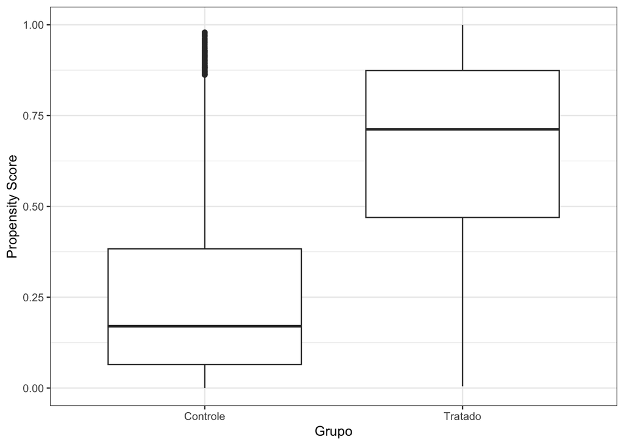

```r
df <- df %>%
  mutate(pscore = p_score,
         grupo = factor(D, levels = c(0,1),
                        labels = c("Controle", "Tratado")))

df %>%
  ggplot(aes(x = grupo, y = pscore)) + geom_boxplot() +
  labs(x = "Grupo", y = "Propensity Score") + theme_bw()
```

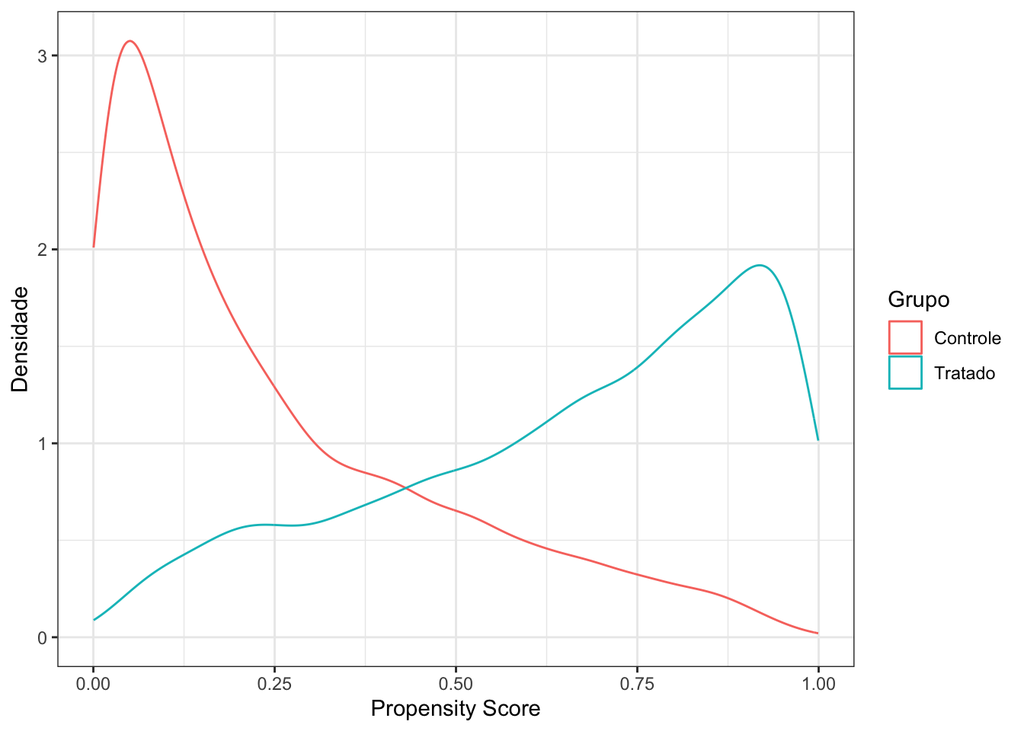

```r
df %>%
  ggplot(aes(x = pscore, colour = grupo)) +
  geom_density() +
  labs(x = "Propensity Score", y = "Densidade", colour = "Grupo") + theme_bw()
```

Há desbalanceamento e falta de overlap ou suporte comum, o que leva à extrapolação.

## Matching

### Intuição

A ideia do matching pode ser ilustrada se notarmos o seguinte. A projeção da reta vermelha para pontos abaixo de $-2$ é de um $y$ médio muito baixo, enquanto que o $y$ médio é muito alto para o controle. O oposto é verificado para a região em que $w_1 > 2$. Portanto, se restringirmos a análise para uma região onde há overlap entre tratados e controles, a necessidade de extrapolação diminui. O que acontece com a estimativa? Vamos comparar a regressão com toda a amostra e com subconjuntos cada vez mais restritos:

```r
reg_sub <- lm(y ~ D + w1, data = df)

reg_sub %>%
  tidy() %>%
  kable(digits = c(0, 2, 3, 2, 3))
```

| term | estimate | std.error | statistic | p.value |
| --- | --- | --- | --- | --- |
| (Intercept) | 4.27 | 0.104 | 41.00 | 0 |
| D | -1.30 | 0.180 | -7.18 | 0 |
| w1 | -0.80 | 0.089 | -8.94 | 0 |

```r
reg_sub <- lm(y ~ D + w1, data = subset(df, w1 > -2 & w1 < 2))

reg_sub %>%
  tidy() %>%
  kable(digits = c(0, 2, 3, 2, 3))
```

| term | estimate | std.error | statistic | p.value |
| --- | --- | --- | --- | --- |
| (Intercept) | 3.46 | 0.069 | 50.52 | 0 |
| D | -1.99 | 0.119 | -16.70 | 0 |
| w1 | -0.35 | 0.066 | -5.32 | 0 |

```r
reg_sub <- lm(y ~ D + w1, data = subset(df, w1 > -1.5 & w1 < 1.5))

reg_sub %>%
  tidy() %>%
  kable(digits = c(0, 2, 3, 2, 3))
```

| term | estimate | std.error | statistic | p.value |
| --- | --- | --- | --- | --- |
| (Intercept) | 2.57 | 0.047 | 55.02 | 0 |
| D | -2.48 | 0.080 | -30.78 | 0 |
| w1 | -0.21 | 0.053 | -3.88 | 0 |

```r
reg_sub <- lm(y ~ D + w1, data = subset(df, w1 > -1 & w1 < 1))

reg_sub %>%
  tidy() %>%
  kable(digits = c(0, 2, 3, 2, 3))
```

| term | estimate | std.error | statistic | p.value |
| --- | --- | --- | --- | --- |
| (Intercept) | 1.41 | 0.029 | 49.57 | 0 |
| D | -2.77 | 0.048 | -57.27 | 0 |
| w1 | -0.17 | 0.043 | -3.93 | 0 |

À medida que restringimos a amostra para regiões com mais overlap, a estimativa se aproxima do efeito causal verdadeiro ($-3$). Isso confirma que o problema estava na extrapolação, não na regressão em si.

A ideia do matching é um pouco diferente do que fizemos acima, pois estamos excluindo as observações que estão no tratamento e que não possuem controle correspondente, e do controle que não possuem tratamento correspondente. Não há erro em excluir os dois tipos de observações, mas sempre temos de nos perguntar qual é o estimando de interesse. Se faço esse procedimento, o meu estimando não é nenhum dos usuais ATT ou ATE.

No matching, nós nos concentramos em estimar o ATT, de forma que procuramos achar observações no controle que são próximas das tratadas, ou seja, excluímos os controles que não são um match para as observações tratadas.

### Matching como imputação

A técnica de matching trata os resultados potenciais como *missing data*. Assim, se pudermos supor CIA com credibilidade, pelo menos com relação a $Y_i(0)$, então podemos imputar esses resultados potenciais e estimar o ATT. A ideia é achar uma unidade o mais similar possível à unidade tratada para servir como contrafactual. Assim, poderíamos computar “diretamente” o ATT, já que teríamos os $Y_i(1)$ e $Y_i(0)$ para cada unidade, este último imputado.

Há dois grandes grupos de métodos de matching: exato e aproximado. Note que o matching, por construção, é um procedimento assimétrico: pegamos cada unidade tratada e buscamos o controle mais parecido. Todos os tratados são usados, mas controles sem match são descartados. Esse procedimento pondera implicitamente pela distribuição de $X$ nos tratados — e portanto estima o **ATT**, não o ATE. Na população com $n \to \infty$ e propensity score verdadeiro, tanto o ATE quanto o ATT são identificados (pois o suporte comum é satisfeito para todos os valores de $X$). Mas o estimador de matching como implementado na prática — buscar controle para cada tratado — estima o ATT. Quem quiser o ATE deve usar IPW, AIPW ou full matching.

### Matching exato

Uma vez que temos as suposições de identificação, podemos discutir os métodos para realizar o matching. O mais simples deles é o matching exato. Nesse método, nós achamos uma unidade (ou mais) que tenham um valor exatamente igual nas covariáveis (ou no propensity score), e imputamos o controle.

### Matching aproximado

Para aproximar o matching, utilizamos alguma noção de distância entre variáveis. Para mais de uma variável, podemos utilizar algumas métricas de distância. A primeira é a distância euclidiana (supondo $K$ variáveis).

$$\lVert X_i - X_j \rVert = \sqrt{(X_i - X_j)'(X_i - X_j)} =
\sqrt{\sum_{k=1}^K(X_{ki} - X_{kj})^2}$$

A distância euclidiana utiliza a escala das proprias variaveis, então é comum usar a distância euclidiana normalizada:

$$\lVert X_i - X_j \rVert = \sqrt{\sum_{k=1}^K\frac{(X_{ki} -
X_{kj})^2}{\hat{\sigma}_k^2}}$$

Outra métrica é a distância de Mahalanobis, que basicamente divide pela covariância (amostral) entre as variáveis em vez da variância. Na prática, a distância euclidiana normalizada é a mais comum.

### Estimando

Uma vez que fizemos o matching entre unidades, qual nosso estimador? Lembrando que o estimando é o ATT. Denotando por $N_T = \sum_{i=1}^N D_i$ o número de unidades tratadas e por $j(i)$ o índice da unidade de controle que é o match da unidade tratada $i$, temos:
$$\widehat{\delta}_{ATT} = \dfrac{1}{N_T} \sum_{D_i=1} (Y_i - Y_{j(i)})$$

```r
result_0 <- matchit(D ~ w1, data = df, method = NULL, distance = 'glm')
summary(result_0)
```

```
##
## Call:
## matchit(formula = D ~ w1, data = df, method = NULL, distance = "glm")
##
## Summary of Balance for All Data:
##          Means Treated Means Control Std. Mean Diff. Var. Ratio eCDF Mean
## distance        0.6549        0.2493          1.5714     1.2566    0.3685
## w1              0.7004       -0.5362          1.6030     0.9132    0.3685
##          eCDF Max
## distance   0.5761
## w1         0.5761
##
## Sample Sizes:
##           Control Treated
## All          5806    4194
## Matched      5806    4194
## Unmatched       0       0
## Discarded       0       0
```

## Aplicação: o dataset LaLonde

O dataset LaLonde é um dos exemplos mais influentes na literatura de inferência causal. O pesquisador @lalonde1986 investigou se métodos econométricos tradicionais eram capazes de recuperar o efeito causal de um programa experimental — o National Supported Work Demonstration (NSW), que oferecia emprego temporário para dar experiência de trabalho. Ele coletou dados de um survey representativo de trabalhadores americanos (PSID) e usou esses trabalhadores como grupo controle, empregando diversos métodos econométricos para estimar o efeito causal. Os resultados foram desastrosos: altamente variáveis dependendo do modelo e subconjunto de dados, frequentemente com sinal errado.

Vamos replicar esse exercício usando matching e propensity score. A variável resposta é `re78` (renda real em 1978), o tratamento é `treat`, e as demais variáveis são covariáveis.

```r
set.seed(1234)
```

```r
lalonde <- fread(here("Dados", "lalonde_nsw.csv"))
psid_data <- fread(here("Dados", "lalonde_psid.csv"))

# Combinamos tratados do NSW com controles do PSID
nsw_treat <- lalonde[lalonde$treat == 1, ]
psid_control <- psid_data[psid_data$treat == 0, ]
dw_data <- rbind(nsw_treat, psid_control)
```

### Diferença bruta

A diferença simples na média entre tratados e controles não é causal, pois os grupos diferem sistematicamente nas covariáveis. Note o resultado — a diferença bruta é negativa, sugerindo que o programa *reduziu* a renda dos participantes. Mas sabemos, pela estimativa experimental, que o efeito verdadeiro é positivo (aproximadamente $1.794). O viés de seleção inverte completamente o sinal. Será que matching e propensity score conseguem corrigir isso?

```r
dw_data %>%
    group_by(treat) %>%
    summarize(`Renda média (1978)` = mean(re78)) %>%
    kableExtra::kable(digits = 0, col.names = c("Tratamento", "Renda média (1978)"))
```

| Tratamento | Renda média (1978) |
| --- | --- |
| 0 | 21554 |
| 1 | 6349 |

### Balanceamento pré-matching

Antes de fazer matching, examinamos o desbalanceamento nas covariáveis. O `matchit` com `method = NULL` calcula o propensity score e as medidas de balanceamento sem realizar matching:

```r
m.out0 <- matchit(treat ~ age + education + hispanic + black + married + nodegree + re74 + re75,
                  data = dw_data,
                  method = NULL,
                  distance = "glm")
summary(m.out0)
```

```
##
## Call:
## matchit(formula = treat ~ age + education + hispanic + black +
##     married + nodegree + re74 + re75, data = dw_data, method = NULL,
##     distance = "glm")
##
## Summary of Balance for All Data:
##           Means Treated Means Control Std. Mean Diff. Var. Ratio eCDF Mean
## distance         0.6364        0.0270          2.1674     8.0268    0.4816
## age             25.8162       34.8506         -1.2627     0.4696    0.2317
## education       10.3459       12.1169         -0.8808     0.4255    0.1091
## hispanic         0.0595        0.0325          0.1139          .    0.0269
## black            0.8432        0.2506          1.6301          .    0.5926
## married          0.1892        0.8663         -1.7287          .    0.6771
## nodegree         0.7081        0.3052          0.8862          .    0.4029
## re74          2095.5737    19428.7458         -3.5471     0.1329    0.4684
## re75          1532.0553    19063.3377         -5.4458     0.0561    0.4695
##           eCDF Max
## distance    0.8817
## age         0.3771
## education   0.4029
## hispanic    0.0269
## black       0.5926
## married     0.6771
## nodegree    0.4029
## re74        0.7292
## re75        0.7736
##
## Sample Sizes:
##           Control Treated
## All          2490     185
## Matched      2490     185
## Unmatched       0       0
## Discarded       0       0
```

O desbalanceamento é severo, especialmente em `black`, `re74` e `re75` — exatamente as variáveis que @lalonde1986 identificou como problemáticas. Vamos agora aplicar matching para tentar corrigir isso.

### Nearest-neighbor matching

Começamos com o matching por vizinho mais próximo (*nearest-neighbor*) no propensity score:

```r
m.out1 <- matchit(treat ~ age + education + hispanic + black + married + nodegree + re74 + re75,
                  data = dw_data,
                  method = "nearest",
                  distance = "glm")
summary(m.out1)
```

```
##
## Call:
## matchit(formula = treat ~ age + education + hispanic + black +
##     married + nodegree + re74 + re75, data = dw_data, method = "nearest",
##     distance = "glm")
##
## Summary of Balance for All Data:
##           Means Treated Means Control Std. Mean Diff. Var. Ratio eCDF Mean
## distance         0.6364        0.0270          2.1674     8.0268    0.4816
## age             25.8162       34.8506         -1.2627     0.4696    0.2317
## education       10.3459       12.1169         -0.8808     0.4255    0.1091
## hispanic         0.0595        0.0325          0.1139          .    0.0269
## black            0.8432        0.2506          1.6301          .    0.5926
## married          0.1892        0.8663         -1.7287          .    0.6771
## nodegree         0.7081        0.3052          0.8862          .    0.4029
## re74          2095.5737    19428.7458         -3.5471     0.1329    0.4684
## re75          1532.0553    19063.3377         -5.4458     0.0561    0.4695
##           eCDF Max
## distance    0.8817
## age         0.3771
## education   0.4029
## hispanic    0.0269
## black       0.5926
## married     0.6771
## nodegree    0.4029
## re74        0.7292
## re75        0.7736
##
## Summary of Balance for Matched Data:
##           Means Treated Means Control Std. Mean Diff. Var. Ratio eCDF Mean
## distance         0.6364        0.2934          1.2200     1.4702    0.0432
## age             25.8162       30.4811         -0.6520     0.4149    0.1196
## education       10.3459       10.3784         -0.0161     0.4745    0.0407
## hispanic         0.0595        0.0649         -0.0229          .    0.0054
## black            0.8432        0.7568          0.2379          .    0.0865
## married          0.1892        0.4595         -0.6901          .    0.2703
## nodegree         0.7081        0.6216          0.1902          .    0.0865
## re74          2095.5737     4499.8428         -0.4920     1.1020    0.0722
## re75          1532.0553     3204.3968         -0.5195     0.7389    0.0605
##           eCDF Max Std. Pair Dist.
## distance    0.5568          1.2200
## age         0.1784          1.3561
## education   0.0919          1.3281
## hispanic    0.0054          0.5257
## black       0.0865          0.9515
## married     0.2703          1.0213
## nodegree    0.0865          0.9036
## re74        0.4162          0.8667
## re75        0.2973          0.9044
##
## Sample Sizes:
##           Control Treated
## All          2490     185
## Matched       185     185
## Unmatched    2305       0
## Discarded       0       0
```

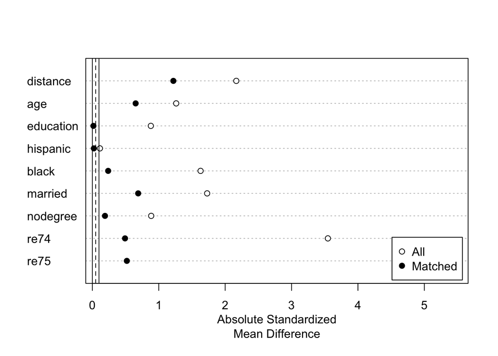

```r
plot(summary(m.out1))
```

O gráfico de *love plot* mostra as diferenças padronizadas antes e depois do matching. Idealmente, todas as covariáveis deveriam ter diferenças próximas de zero após o matching.

### Full matching

Uma alternativa é o *full matching*, que usa todas as observações (sem descarte) e cria subclasses de tamanho variável:

```r
m.out2 <- matchit(treat ~ age + education + hispanic + black + married + nodegree + re74 + re75,
                  data = dw_data,
                  method = "full",
                  distance = "glm")
summary(m.out2)
```

```
##
## Call:
## matchit(formula = treat ~ age + education + hispanic + black +
##     married + nodegree + re74 + re75, data = dw_data, method = "full",
##     distance = "glm")
##
## Summary of Balance for All Data:
##           Means Treated Means Control Std. Mean Diff. Var. Ratio eCDF Mean
## distance         0.6364        0.0270          2.1674     8.0268    0.4816
## age             25.8162       34.8506         -1.2627     0.4696    0.2317
## education       10.3459       12.1169         -0.8808     0.4255    0.1091
## hispanic         0.0595        0.0325          0.1139          .    0.0269
## black            0.8432        0.2506          1.6301          .    0.5926
## married          0.1892        0.8663         -1.7287          .    0.6771
## nodegree         0.7081        0.3052          0.8862          .    0.4029
## re74          2095.5737    19428.7458         -3.5471     0.1329    0.4684
## re75          1532.0553    19063.3377         -5.4458     0.0561    0.4695
##           eCDF Max
## distance    0.8817
## age         0.3771
## education   0.4029
## hispanic    0.0269
## black       0.5926
## married     0.6771
## nodegree    0.4029
## re74        0.7292
## re75        0.7736
##
## Summary of Balance for Matched Data:
##           Means Treated Means Control Std. Mean Diff. Var. Ratio eCDF Mean
## distance         0.6364        0.6338          0.0091     0.9750    0.0034
## age             25.8162       23.5784          0.3128     0.9777    0.0779
## education       10.3459       10.1846          0.0802     0.6511    0.0258
## hispanic         0.0595        0.0722         -0.0537          .    0.0127
## black            0.8432        0.8485         -0.0144          .    0.0052
## married          0.1892        0.1337          0.1417          .    0.0555
## nodegree         0.7081        0.7121         -0.0087          .    0.0040
## re74          2095.5737     3369.8141         -0.2608     1.4024    0.0443
## re75          1532.0553     2341.0260         -0.2513     0.7348    0.0299
##           eCDF Max Std. Pair Dist.
## distance    0.1243          0.0059
## age         0.2923          1.2717
## education   0.1181          1.3984
## hispanic    0.0127          0.1697
## black       0.0052          1.9737
## married     0.0555          0.3408
## nodegree    0.0040          1.3976
## re74        0.5207          2.2676
## re75        0.2243          1.9077
##
## Sample Sizes:
##               Control Treated
## All           2490.       185
## Matched (ESS)   23.03     185
## Matched       2490.       185
## Unmatched        0.         0
## Discarded        0.         0
```

### Estimação do ATT

Com o matching feito, estimamos o ATT usando regressão com interações nas covariáveis (para ajuste residual) e erros-padrão clusterizados por subclasse:

```r
# Com nearest-neighbor
m.data1 <- match.data(m.out1)
fit1 <- lm(re78 ~ treat * (age + education + hispanic + black + married +
                             nodegree + re74 + re75),
           data = m.data1, weights = weights)

avg_comparisons(fit1, variables = "treat",
                vcov = ~subclass, newdata = subset(treat == 1))
```

```
##
##  Estimate Std. Error    z Pr(>|z|)   S 2.5 % 97.5 %
##      1905        872 2.18    0.029 5.1   195   3614
##
## Term: treat
## Type:  response
## Comparison: 1 - 0
```

```r
# Com full matching
m.data2 <- match.data(m.out2)
fit2 <- lm(re78 ~ treat * (age + education + hispanic + black + married +
                             nodegree + re74 + re75),
           data = m.data2, weights = weights)

avg_comparisons(fit2, variables = "treat",
                vcov = ~subclass, newdata = subset(treat == 1))
```

```
##
##  Estimate Std. Error    z Pr(>|z|)    S 2.5 % 97.5 %
##      2629        612 4.29   <0.001 15.8  1429   3829
##
## Term: treat
## Type:  response
## Comparison: 1 - 0
```

A estimativa experimental do NSW é de aproximadamente $1.794. Compare as estimativas do nearest-neighbor e do full matching com essa referência. Qual método chegou mais perto? Por quê? Note que nenhuma das estimativas é *exatamente* igual ao benchmark — isso ilustra que matching com dados observacionais é uma aproximação, não uma garantia.

## Recomendações Práticas sobre Matching

Rotina ou algoritmo:

1. Defina o que é proximidade: alguma distância de medida para determinar se um caso é um bom match e quais variáveis utilizar. Em geral, distância euclidiana.
2. Implemente o método do match.
3. Avalie a qualidade do método, por meio do balanceamento antes e depois do match. Se necessário, altere o passo 1 ou 2 e itere.
4. Faça a inferência sobre o efeito causal do tratamento sobre a resposta, dado o matching feito em 3.

### Avaliação do matching feito

1. É melhor usar matching exato ou aproximado do que propensity score matching [cf. @kingnielsen2019]. O argumento é o seguinte: o propensity score é um escalar que resume todas as covariáveis. Duas unidades podem ter o mesmo $\hat{\pi}(X)$ mas perfis de covariáveis completamente diferentes — por exemplo, um jovem com alta educação e um idoso com baixa educação podem ter a mesma probabilidade estimada de tratamento. Quando se faz matching por propensity score, é possível que o balanceamento nas covariáveis individuais **piore** à medida que os pares ficam mais próximos no score — o que @kingnielsen2019 chamam de *propensity score paradox*. Isso aumenta a dependência do modelo de outcome, exatamente o que matching deveria evitar.

   É importante notar que esse problema é de **amostra finita**: na população, o teorema de Rosenbaum-Rubin garante que condicionar no propensity score verdadeiro $\pi(X)$ produz balanceamento perfeito em todas as covariáveis (pois $D \perp X | \pi(X)$). Com infinitas observações para cada valor do score, a média sobre todas as unidades com $\pi(X) = c$ produz balanceamento exato. O paradoxo surge porque, na amostra, o score é estimado (não verdadeiro), o número de unidades com score similar é pequeno, e o matching seleciona *um* controle em vez de promediar sobre todos.

   Métodos que trabalham diretamente no espaço das covariáveis — como CEM, Mahalanobis, ou entropy balancing — monitoram diretamente o balanceamento em vez de delegá-lo a um escalar estimado. Note que a crítica se aplica ao propensity score como **métrica de distância para matching**, não a outros usos: IPW (ponderação), subclassificação e estimadores duplamente robustos (AIPW) continuam válidos.
2. Não devemos fazer teste de hipótese para checar que o balanceamento após matching é melhor do que antes (amostra menor reduz o poder do teste de detectar desbalanceamento. Além disso, não há superpopulação alvo da inferência, pois balanceamento é uma propriedade de uma amostra em particular) [cf. @austin2009].
3. Além de comparar médias, é recomendado comparar variâncias ou desvios-padrão [@austin2009]. Por exemplo, razão de variâncias.
4. Jamais use a variável resposta para fazer o matching.
5. Matching com reposição gera dificuldades para calcular o erro padrão, já que a mesma unidade de controle pode servir de match para múltiplos tratados, criando dependência entre as observações. Abadie e Imbens (2006) mostram que o bootstrap ingênuo é **inconsistente** para o erro padrão do estimador de nearest-neighbor matching — ou seja, não converge para o valor correto mesmo com $n \to \infty$. O pacote `MatchIt` em R lida com isso ao recomendar o uso de erros-padrão clusterizados por subclasse (`vcov = ~subclass`) na análise pós-matching.

## Métodos modernos de matching

### Coarsened Exact Matching (CEM)

O Coarsened Exact Matching [CEM, @iacuskingporro2012] é um método que busca combinar a simplicidade do matching exato com a flexibilidade do matching aproximado. A ideia é “engrossar” (*coarsen*) temporariamente as covariáveis — por exemplo, agrupar idades em faixas etárias (18–25, 26–35, etc.) — e então realizar matching exato nas versões engrossadas. As observações que não encontram match exato nas covariáveis engrossadas são descartadas. Após o matching, a análise é feita com os valores originais (não engrossados) das covariáveis.

A vantagem principal do CEM é que ele garante um nível máximo de desbalanceamento ex ante: o pesquisador escolhe o grau de engrossamento e, portanto, controla diretamente o trade-off entre qualidade do match e tamanho da amostra resultante. Além disso, o CEM satisfaz uma propriedade chamada *monotonic imbalance bounding*: engrossar menos (faixas mais estreitas) nunca piora o balanceamento.

```r
m.cem <- matchit(treat ~ age + education + hispanic + black + married + nodegree + re74 + re75,
                 data = dw_data, method = "cem")
summary(m.cem)
```

```
##
## Call:
## matchit(formula = treat ~ age + education + hispanic + black +
##     married + nodegree + re74 + re75, data = dw_data, method = "cem")
##
## Summary of Balance for All Data:
##           Means Treated Means Control Std. Mean Diff. Var. Ratio eCDF Mean
## age             25.8162       34.8506         -1.2627     0.4696    0.2317
## education       10.3459       12.1169         -0.8808     0.4255    0.1091
## hispanic         0.0595        0.0325          0.1139          .    0.0269
## black            0.8432        0.2506          1.6301          .    0.5926
## married          0.1892        0.8663         -1.7287          .    0.6771
## nodegree         0.7081        0.3052          0.8862          .    0.4029
## re74          2095.5737    19428.7458         -3.5471     0.1329    0.4684
## re75          1532.0553    19063.3377         -5.4458     0.0561    0.4695
##           eCDF Max
## age         0.3771
## education   0.4029
## hispanic    0.0269
## black       0.5926
## married     0.6771
## nodegree    0.4029
## re74        0.7292
## re75        0.7736
##
## Summary of Balance for Matched Data:
##           Means Treated Means Control Std. Mean Diff. Var. Ratio eCDF Mean
## age             24.9569       24.9639         -0.0010     1.0568    0.0082
## education       10.5259       10.5057          0.0100     1.0467    0.0027
## hispanic         0.0086        0.0086          0.0000          .    0.0000
## black            0.8966        0.8966         -0.0000          .    0.0000
## married          0.2500        0.2500         -0.0000          .    0.0000
## nodegree         0.6724        0.6724         -0.0000          .    0.0000
## re74          1852.5830     5084.9418         -0.6615     0.9346    0.0911
## re75          1314.5073     4929.6785         -1.1230     0.4560    0.1246
##           eCDF Max Std. Pair Dist.
## age         0.0991          0.1257
## education   0.0187          0.1059
## hispanic    0.0000          0.0000
## black       0.0000          0.0000
## married     0.0000          0.0000
## nodegree    0.0000          0.0000
## re74        0.5774          0.7826
## re75        0.5595          1.3340
##
## Sample Sizes:
##               Control Treated
## All           2490.       185
## Matched (ESS)   50.79     116
## Matched        131.       116
## Unmatched     2359.        69
## Discarded        0.         0
```

```r
m.data.cem <- match.data(m.cem)
fit.cem <- lm(re78 ~ treat * (age + education + black + married +
                                nodegree + re74 + re75),
              data = m.data.cem, weights = weights)

avg_comparisons(fit.cem, variables = "treat",
                vcov = ~subclass, newdata = subset(treat == 1))
```

```
##
##  Estimate Std. Error     z Pr(>|z|)   S 2.5 % 97.5 %
##       316       1460 0.216    0.829 0.3 -2546   3178
##
## Term: treat
## Type:  response
## Comparison: 1 - 0
```

Note o trade-off: o CEM descarta observações que não encontram match exato nas covariáveis engrossadas. Compare o número de observações usadas com o nearest-neighbor matching.

### Entropy Balancing

O entropy balancing [@hainmueller2012] adota uma abordagem diferente: em vez de selecionar observações, ele repesa as unidades do grupo de controle de modo que momentos selecionados (média, variância e, opcionalmente, assimetria) das covariáveis no controle repesado sejam exatamente iguais aos do grupo tratado. Isso é feito resolvendo um problema de otimização convexa que minimiza a entropia dos pesos em relação a pesos uniformes, sujeito às restrições de balanceamento.

Na prática, o entropy balancing produz pesos suaves (sem descarte de observações) e garante balanceamento exato nos momentos especificados, eliminando a necessidade de iterar entre matching e checagem de balanceamento. É uma alternativa atraente quando o número de covariáveis é moderado e o pesquisador quer evitar a perda de observações associada ao matching tradicional.

```r
library(ebal)

# Separar tratados e controles
treated <- dw_data[dw_data$treat == 1, ]
control <- dw_data[dw_data$treat == 0, ]

covs <- c("age", "education", "hispanic", "black", "married", "nodegree", "re74", "re75")

eb <- ebalance(Treatment = dw_data$treat,
               X = dw_data[, ..covs])

# Médias das covariáveis: tratados vs controles repesados
round(eb$co.xdata, 3)
```

[output not shown]

[output cut: 2476 more lines]

```r
# Estimação do ATT com pesos do entropy balancing
dw_data$eb_weights <- ifelse(dw_data$treat == 1, 1, eb$w)
fit.eb <- lm(re78 ~ treat, data = dw_data, weights = eb_weights)
summary(fit.eb)$coefficients["treat", ]
```

```
##     Estimate   Std. Error      t value     Pr(>|t|)
## -31752.34151    554.38360    -57.27504      0.00000
```

Note que, diferente do matching, nenhuma observação é descartada — todas recebem pesos positivos. O balanceamento nas médias é exato por construção.

## Análise de sensibilidade: Rosenbaum Bounds

Uma limitação fundamental de todos os métodos baseados em seleção em observáveis é que a suposição de independência condicional (CIA) não é testável. Pode haver variáveis não observadas que afetam simultaneamente o tratamento e o resultado, invalidando o matching.

@rosenbaum2002 propôs um framework para avaliar a sensibilidade dos resultados a esse tipo de confundimento oculto. A ideia é perguntar: quão forte teria que ser a influência de um confounder não observado para reverter a conclusão do estudo?

Formalmente, define-se um parâmetro $\Gamma \geq 1$ tal que, para duas unidades $i$ e $j$ com as mesmas covariáveis observadas $X$, a razão de odds de receber tratamento satisfaz:

$$\frac{1}{\Gamma} \leq \frac{P(D_i =
1|X)/P(D_i = 0|X)}{P(D_j = 1|X)/P(D_j = 0|X)} \leq \Gamma$$

Quando $\Gamma = 1$, não há confundimento oculto (as unidades com mesmas covariáveis têm a mesma probabilidade de tratamento). À medida que $\Gamma$ aumenta, permitimos maiores desvios. O pesquisador então recomputa os p-valores e intervalos de confiança para diferentes valores de $\Gamma$ e reporta o valor crítico $\Gamma^*$ no qual a conclusão se inverte.

Por exemplo, se $\Gamma^* = 2$, isso significa que um confounder oculto precisaria dobrar a chance de tratamento (para unidades com mesmas covariáveis observadas) para invalidar o resultado. Se $\Gamma^* = 1.1$, o resultado é muito frágil a confundimento oculto.

Essa análise não prova que o resultado é válido, mas permite uma avaliação quantitativa da robustez da conclusão — e é considerada boa prática em qualquer estudo que dependa de seleção em observáveis.

Uma implementação moderna dessa ideia é o pacote `sensemakr` [@cinellihazlett2020], que permite avaliar a sensibilidade de estimativas de regressão a confundidores não-observados. A ideia é perguntar: quão forte precisaria ser um confounder omitido — em termos de sua capacidade de explicar variação no tratamento e no resultado — para invalidar a conclusão?

```r
library(sensemakr)

# Regressão com os dados matched (nearest-neighbor)
fit_sens <- lm(re78 ~ treat + age + education + black + married +
                 nodegree + re74 + re75,
               data = m.data1)

# Análise de sensibilidade: quão forte teria que ser um confounder
# omitido para anular o efeito de treat?
sens <- sensemakr(fit_sens,
                  treatment = "treat",
                  benchmark_covariates = "re74",
                  kd = 1:3)

summary(sens)
```

```
## Sensitivity Analysis to Unobserved Confounding
##
## Model Formula: re78 ~ treat + age + education + black + married + nodegree +
##     re74 + re75
##
## Null hypothesis: q = 1 and reduce = TRUE
## -- This means we are considering biases that reduce the absolute value of the current estimate.
## -- The null hypothesis deemed problematic is H0:tau = 0
##
## Unadjusted Estimates of 'treat':
##   Coef. estimate: 1069.411
##   Standard Error: 819.2061
##   t-value (H0:tau = 0): 1.3054
##
## Sensitivity Statistics:
##   Partial R2 of treatment with outcome: 0.0047
##   Robustness Value, q = 1: 0.0664
##   Robustness Value, q = 1, alpha = 0.05: 0
##
## Verbal interpretation of sensitivity statistics:
##
## -- Partial R2 of the treatment with the outcome: an extreme confounder (orthogonal to the covariates) that explains 100% of the residual variance of the outcome, would need to explain at least 0.47% of the residual variance of the treatment to fully account for the observed estimated effect.
##
## -- Robustness Value, q = 1: unobserved confounders (orthogonal to the covariates) that explain more than 6.64% of the residual variance of both the treatment and the outcome are strong enough to bring the point estimate to 0 (a bias of 100% of the original estimate). Conversely, unobserved confou…
##
## -- Robustness Value, q = 1, alpha = 0.05: unobserved confounders (orthogonal to the covariates) that explain more than 0% of the residual variance of both the treatment and the outcome are strong enough to bring the estimate to a range where it is no longer 'statistically different' from 0 (a bia…
##
## Bounds on omitted variable bias:
##
## --The table below shows the maximum strength of unobserved confounders with association with the treatment and the outcome bounded by a multiple of the observed explanatory power of the chosen benchmark covariate(s).
##
##  Bound Label R2dz.x R2yz.dx Treatment Adjusted Estimate Adjusted Se Adjusted T
##      1x re74 0.0137  0.0103     treat          882.7972    821.7634     1.0743
##      2x re74 0.0275  0.0206     treat          693.4843    823.2179     0.8424
##      3x re74 0.0412  0.0310     treat          501.3841    824.7080     0.6080
##  Adjusted Lower CI Adjusted Upper CI
##          -733.2474          2498.842
##          -925.4207          2312.389
##         -1120.4513          2123.219
```

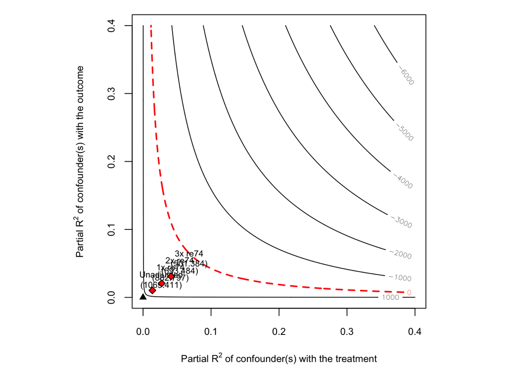

```r
plot(sens)
```

O gráfico mostra as combinações de força do confounder (em termos de $R^2$ parcial com o tratamento e com o resultado) que anulariam o efeito estimado. As linhas de *benchmark* mostram onde estariam confounders com a mesma força explicativa que `re74` — uma das covariáveis mais importantes. Se o confounder precisaria ser muito mais forte que qualquer covariável observada para invalidar o resultado, isso indica robustez.

## Matching e Diferença em Diferenças

Uma conexão importante entre matching e outros métodos de inferência causal é o uso de propensity scores e matching em estimadores de Diferença em Diferenças (DiD). O estimador de @callawaysantanna2021 para DiD com tratamento escalonado (*staggered treatment*), implementado no pacote `did` em R, utiliza propensity score e outcome regression “por baixo dos panos” para construir estimadores duplamente robustos (*doubly robust*) do ATT em cada par grupo-período.

A ideia é a seguinte: em vez de simplesmente comparar médias antes e depois entre tratados e controles (como no DiD clássico), o estimador de Callaway e Sant’Anna repesa as unidades do grupo de controle usando o propensity score (estimado via logit com covariáveis pré-tratamento), de modo que o grupo de controle repesado se assemelhe ao grupo tratado nas covariáveis. Essa repesagem é combinada com uma regressão do outcome, produzindo um estimador que é consistente se *pelo menos um* dos dois modelos (propensity score ou outcome regression) estiver correto — daí a propriedade de dupla robustez.

Isso mostra que matching e propensity scores não são apenas ferramentas para estudos cross-section: eles desempenham um papel central em métodos modernos de painel, melhorando a plausibilidade da hipótese de tendências paralelas condicionais.

## Conclusão

**Para refletir:** todos os métodos deste capítulo dependem da suposição de que observamos *todas* as variáveis relevantes (CIA). Na prática, como saber se essa suposição é razoável? A análise de sensibilidade (`sensemakr`, Rosenbaum bounds) ajuda a quantificar a fragilidade, mas não prova que a suposição é verdadeira. Quando você escolheria matching sobre IPW? E quando usaria estimadores duplamente robustos?

Em resumo, matching é uma ferramenta poderosa para estimar efeitos causais em estudos observacionais, mas requer atenção ao balanceamento, à escolha do método e à plausibilidade da suposição de independência condicional. Métodos modernos como CEM e entropy balancing oferecem melhorias importantes sobre o matching por nearest-neighbor tradicional. E a análise de sensibilidade é uma boa prática indispensável para avaliar a robustez dos resultados a confundimento oculto. No próximo capítulo, veremos uma abordagem alternativa — variáveis instrumentais — que permite a identificação causal mesmo quando a seleção em observáveis não é crível.